# 01_eda

## Initial EDA of cleaned series data

```python
import sys
from pathlib import Path
import datetime as dt
import pandas as pd
from tours import config, dataset
import numpy as np
from statsmodels.tsa.seasonal import seasonal_decompose, MSTL
from statsmodels.tsa.stattools import adfuller
from statsmodels.graphics.tsaplots import plot_acf, plot_pacf
import plotly.graph_objects as go
from plotly.subplots import make_subplots
import plotly.express as px

from statsforecast import StatsForecast
from sktime.forecasting.model_selection import ExpandingWindowSplitter


from statsmodels.tsa.statespace.sarimax import SARIMAX
from sklearn.model_selection import TimeSeriesSplit
from pmdarima import auto_arima
```

```python
df = dataset.load_clean_data()
df = dataset.cutoff_series(df)
train, val, split = dataset.split_data(df)
```

```
2026-09-17 12:11:39 [INFO] tours.dataset: Train df runs from 2018-01-01 00:00:00 to 2023-12-31 00:00:00
2026-09-17 12:11:39 [INFO] tours.dataset: Val df runs from 2024-01-01 00:00:00 to 2025-04-30 00:00:00
2026-09-17 12:11:39 [INFO] tours.dataset: Test df runs from 2025-05-01 00:00:00 to 2026-08-01 00:00:00
```

```python
df.describe()
```

|  | tour_year | tour_month | tour_day | day_of_week | num_guides | headcount |
| --- | --- | --- | --- | --- | --- | --- |
| count | 3135.000000 | 3135.000000 | 3135.000000 | 3135.000000 | 3135.000000 | 3135.000000 |
| mean | 2021.806061 | 6.354067 | 15.720255 | 3.000957 | 1.170016 | 43.576555 |
| std | 2.485316 | 3.428874 | 8.801826 | 1.999920 | 0.979102 | 35.452421 |
| min | 2018.000000 | 1.000000 | 1.000000 | 0.000000 | 0.000000 | 0.000000 |
| 25% | 2020.000000 | 3.000000 | 8.000000 | 1.000000 | 1.000000 | 0.000000 |
| 50% | 2022.000000 | 6.000000 | 16.000000 | 3.000000 | 1.000000 | 44.500000 |
| 75% | 2024.000000 | 9.000000 | 23.000000 | 5.000000 | 2.000000 | 66.750000 |
| max | 2026.000000 | 12.000000 | 31.000000 | 6.000000 | 9.000000 | 348.500000 |

```python
df.info()
```

```
<class 'pandas.core.frame.DataFrame'>
DatetimeIndex: 3135 entries, 2018-01-01 to 2026-08-01
Freq: D
Data columns (total 10 columns):
 #   Column       Non-Null Count  Dtype
---  ------       --------------  -----
 0   tour_year    3135 non-null   int64
 1   tour_month   3135 non-null   int64
 2   tour_day     3135 non-null   int64
 3   day_name     3135 non-null   object
 4   day_of_week  3135 non-null   int64
 5   num_guides   3135 non-null   int64
 6   headcount    3135 non-null   float64
 7   covid_flag   3135 non-null   object
 8   xmas_flag    3135 non-null   bool
 9   source       3135 non-null   object
dtypes: bool(1), float64(1), int64(5), object(3)
memory usage: 312.5+ KB
```

```python
fig = px.line(df["headcount"],title="Number of Attendees Jan 2018 - Aug 2026")
fig.show()
```

## Whole Series Observation

- There is a break from March 2020 to the beginning of 2022 that covers the covid period. Tours weren't running in this period so we don't have a complete series from 2018 onwards. Either we need to train only on the post-covid period or use a model that can account for this break in the time-series data
- Spikes always occur around the chiristmas/New Year holiday
- There appears to be a yearly seasonal effect. Highs in the summer period and lows in the winter period. Also secondary peaks around Mar/April for some years

```python
fig = px.line(df[df["tour_year"]==2025]["headcount"],title="Number of Attendees 2025")
fig.show()
```

```python
order = ["Monday", "Tuesday", "Wednesday", "Thursday", "Friday", "Saturday", "Sunday"]
# drop covid period and christmas
df_drop = df[(df["covid_flag"]!="covid") & (df["xmas_flag"]==False)]
fig = px.box(
    df_drop,
    x=df_drop.index.day_name(),
    y="headcount",
    category_orders={"x": order},
    labels={"x": "weekday"},
    title="Attendance by day of week excl covid & xmas",
)
fig.show()

day_of_week_sd = df_drop.groupby(by="day_name")["headcount"].std()
day_of_week_mean = df_drop.groupby(by="day_name")["headcount"].mean()
day_of_week_stats = pd.DataFrame({"Standard Deviation":day_of_week_sd, "Mean": day_of_week_mean}).reindex(order)
day_of_week_stats
```

| day_name | Standard Deviation | Mean |
| --- | --- | --- |
| Monday | 30.381087 | 63.834936 |
| Tuesday | 28.900460 | 61.608626 |
| Wednesday | 28.495205 | 60.459936 |
| Thursday | 29.040745 | 60.921725 |
| Friday | 29.272033 | 63.869427 |
| Saturday | 26.623543 | 59.906051 |
| Sunday | 24.436157 | 51.464744 |

## Weekly Seasonality

- There is also weekly seasonality present in the data. We can see that weekends consistently show a smaller number of attendees.

```python
df["rolling_mean_7d"] = df["headcount"].rolling("7D", min_periods=7).mean()
df["rolling_mean_30d"] = df["headcount"].rolling("30D", min_periods=30).mean()

fig = px.line(df[["rolling_mean_7d", "rolling_mean_30d"]],title="Number of Attendees Rolling Means")
fig.update_traces(opacity=0.35, line_width=1, selector=dict(name="headcount"))
fig.update_traces(line_width=2.5, selector=dict(name="rolling_mean_30d"))
fig.show()
```

## When does the series recover in 2022?

```python
fig = px.line(df[df["tour_year"]==2022]["headcount"],title="Number of Attendees 2022")
fig.show()

zero_days = pd.Series(df[(df["headcount"]==0) & (df["tour_year"]==2022)].index)
print(zero_days)
```

```
0     2022-01-01
1     2022-01-02
2     2022-01-03
3     2022-01-04
4     2022-01-06
         ...
131   2022-09-13
132   2022-09-22
133   2022-09-27
134   2022-10-17
135   2022-12-25
Name: tour_date, Length: 136, dtype: datetime64[ns]
```

- Excluding Christmas, 2022 had 135 days where the tour didn't run or attendance was zero.
- It only gets to a more consistent pattern after 17 October
- If we are really conservative, we can cut the series to run only from 17 Oct 2022 to end of series
- further exploration at this point will be based on the post Oct 17 2022 period

## Seasonal Decomposition

```python
post_covid_df = df[df["covid_flag"]=="post_covid"]
result = seasonal_decompose(post_covid_df["headcount"], model='additive', period=365)

fig = make_subplots(rows=4, cols=1, shared_xaxes=True,
                     subplot_titles=("Headcount", "Trend", "Seasonal (yearly)", "Residual"))

fig.add_trace(go.Scatter(x=post_covid_df.index, y=post_covid_df["headcount"] , name="Headcount"), row=1, col=1)
fig.add_trace(go.Scatter(x=result.trend.index, y=result.trend, name="Trend"), row=2, col=1)
fig.add_trace(go.Scatter(x=result.seasonal.index, y=result.seasonal, name="Seasonality"), row=3, col=1)
fig.add_trace(go.Scatter(x=result.resid.index, y=result.resid, name="Residual"), row=4, col=1)

fig.update_layout(height=1200, width=1000, title_text = "Yearly Seasonality Post Covid")
fig.update_xaxes(showticklabels=True)
fig.show()
```

```python
# post_covid_df.loc[post_covid_df["xmas_flag"], "headcount"] = np.nan
# post_covid_df["headcount"] = post_covid_df["headcount"].ffill()

mstl_result = MSTL(post_covid_df["headcount"], periods=(7,365)).fit()
mstl_result.seasonal["seasonal_7"]

fig = make_subplots(rows=5, cols=1, shared_xaxes=True,
                     subplot_titles=("Headcount", "Trend", "Seasonal (7)", "Seasonal (365)", "Residual"))

fig.add_trace(go.Scatter(x=post_covid_df.index, y=post_covid_df["headcount"] , name="Headcount"), row=1, col=1)
fig.add_trace(go.Scatter(x=mstl_result.trend.index, y=mstl_result.trend, name="Trend"), row=2, col=1)
fig.add_trace(go.Scatter(x=mstl_result.seasonal.index, y=mstl_result.seasonal["seasonal_7"], name="Seasonal 7"), row=3, col=1)
fig.add_trace(go.Scatter(x=mstl_result.seasonal.index, y=mstl_result.seasonal["seasonal_365"], name="Seasonal 365"), row=4, col=1)
fig.add_trace(go.Scatter(x=mstl_result.resid.index, y=mstl_result.resid, name="Residual"), row=5, col=1)

fig.update_layout(height=1200, width=1000, title_text = "MSTL Seasonality Post Covid")
fig.update_xaxes(showticklabels=True)
fig.show()
```

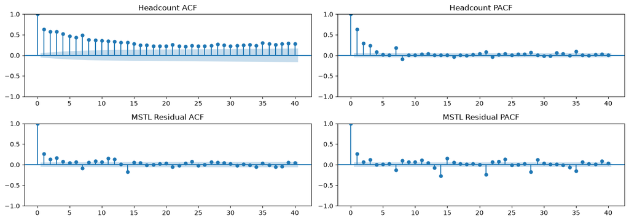

```python
import matplotlib.pyplot as plt

fig, axes = plt.subplots(2, 2, figsize=(14, 5))

plot_acf(post_covid_df["headcount"].dropna(), lags=40, ax=axes[0][0])
axes[0][0].set_title("Headcount ACF")

plot_pacf(post_covid_df["headcount"].dropna(), lags=40, method="ywm", ax=axes[0][1])
axes[0][1].set_title("Headcount PACF")

plot_acf(mstl_result.resid.dropna(), lags=40, ax=axes[1][0])
axes[1][0].set_title("MSTL Residual ACF")

plot_pacf(mstl_result.resid.dropna(), lags=40, method="ywm", ax=axes[1][1])
axes[1][1].set_title("MSTL Residual PACF")

plt.tight_layout()
plt.show()
```

```python
pre_covid_df = df[df["covid_flag"]=="pre_covid"]
result = seasonal_decompose(pre_covid_df["headcount"], model='additive', period=7)

fig = make_subplots(rows=4, cols=1, shared_xaxes=True,
                     subplot_titles=("Headcount", "Trend", "Seasonal (yearly)", "Residual"))

fig.add_trace(go.Scatter(x=pre_covid_df.index, y=pre_covid_df["headcount"] , name="Headcount"), row=1, col=1)
fig.add_trace(go.Scatter(x=result.trend.index, y=result.trend, name="Trend"), row=2, col=1)
fig.add_trace(go.Scatter(x=result.seasonal.index, y=result.seasonal, name="Seasonality"), row=3, col=1)
fig.add_trace(go.Scatter(x=result.resid.index, y=result.resid, name="Residual"), row=4, col=1)

fig.update_layout(height=1200, width=1000, title_text = "Yearly Seasonality Pre Covid")
fig.update_xaxes(showticklabels=True)
fig.show()
```

```python
px.line(pre_covid_df["headcount"])
```

```python
num_rows = df.shape[0]
train = df[df.tour_year < 2025]
val = df[df.tour_year == 2025]
test = df[df.tour_year == 2026]

print(f'full df num rows: {num_rows}\n train num rows: {len(train)}\ntrain perc: {len(train)/num_rows*100}\n')
print(f'full df num rows: {num_rows}\n val num rows: {len(val)}\n val perc: {len(val)/num_rows*100}\n')
print(f'full df num rows: {num_rows}\n test num rows: {len(test)}\n test perc: {len(test)/num_rows*100}')
```

```
full df num rows: 3135
 train num rows: 2557
train perc: 81.56299840510367

full df num rows: 3135
 val num rows: 365
 val perc: 11.64274322169059

full df num rows: 3135
 test num rows: 213
 test perc: 6.794258373205741
```

```python
# TRAIN_RANGE = [config.START_DATE, "2023-12-31"]
# VAL_RANGE = ["2024-01-01", "2025-04-30"]
# TEST_RANGE = ["2025-05-01", config.CUTOFF_DATE]
import logging
logger = logging.getLogger(__name__)


def split_data(df):
    train_df = df.loc[config.TRAIN_RANGE[0]: config.TRAIN_RANGE[1]]
    val_df = df.loc[config.VAL_RANGE[0]: config.VAL_RANGE[1]]
    test_df = df.loc[config.TEST_RANGE[0]: config.TEST_RANGE[1]]

    logger.info("Train df runs from %s to %s", train_df.index[0], train_df.index[-1])
    logger.info("Val df runs from %s to %s", val_df.index[0], val_df.index[-1])
    logger.info("Test df runs from %s to %s", test_df.index[0], test_df.index[-1])


    return (train_df, val_df, test_df)

train, val, test = split_data(df)
train.head()
val.head()
test.head()
```

```
2026-09-17 12:11:41 [INFO] __main__: Train df runs from 2018-01-01 00:00:00 to 2023-12-31 00:00:00
2026-09-17 12:11:41 [INFO] __main__: Val df runs from 2024-01-01 00:00:00 to 2025-04-30 00:00:00
2026-09-17 12:11:41 [INFO] __main__: Test df runs from 2025-05-01 00:00:00 to 2026-08-01 00:00:00
```

| tour_date | tour_year | tour_month | tour_day | day_name | day_of_week | num_guides | headcount | covid_flag | xmas_flag | source | rolling_mean_7d | rolling_mean_30d |
| --- | --- | --- | --- | --- | --- | --- | --- | --- | --- | --- | --- | --- |
| 2025-05-01 | 2025 | 5 | 1 | Thursday | 4 | 1 | 69.5 | post_covid | False | all_bookings_raw | 52.071429 | 63.983333 |
| 2025-05-02 | 2025 | 5 | 2 | Friday | 5 | 1 | 70.5 | post_covid | False | all_bookings_raw | 53.214286 | 64.133333 |
| 2025-05-03 | 2025 | 5 | 3 | Saturday | 6 | 1 | 64.5 | post_covid | False | all_bookings_raw | 54.000000 | 64.566667 |
| 2025-05-04 | 2025 | 5 | 4 | Sunday | 0 | 1 | 31.0 | post_covid | False | all_bookings_raw | 52.714286 | 63.166667 |
| 2025-05-05 | 2025 | 5 | 5 | Monday | 1 | 1 | 43.0 | post_covid | False | all_bookings_raw | 52.571429 | 63.133333 |

```python
post_covid_df_count = post_covid_df.reset_index(names="date")[["date","headcount"]]
post_covid_df_count["date"] = pd.to_datetime(post_covid_df_count["date"])


# train_df = post_covid_df_count.rename(columns={"date": "ds", "headcount": "y"})
# train_df["unique_id"] = "store_001"
# train_df = train_df[["unique_id", "ds", "y"]]
```

```python
H = 30

def fit_naive(y_train):
    last_day = y_train.values[-1]
    return np.tile(last_day, int(np.ceil(H)))[:H]

def fit_7d_seasonal_naive(y_train):
    last_week = y_train.values[-7:]
    return np.tile(last_week, int(np.ceil(H / 7)))[:H]

def fit_365d_seasonal_naive(y_train):
    last_year = y_train.values[-365:]
    return np.tile(last_year, int(np.ceil(H / 365)))[:H]

def fit_sarima(y_train):
    model = SARIMAX(
        y_train,
        order=(1, 1, 1),
        seasonal_order=(1, 1, 1, 7),
    ).fit(disp=False)
    return model.forecast(steps=H).values


def fit_autoarima(y_train):
    model = auto_arima(
        y_train,
        seasonal=True,
        m=7,
        stepwise=True,
        suppress_warnings=True,
        error_action='ignore',
    )
    return model.predict(n_periods=H)


MODELS = {
    'naive':                fit_naive,
    'seasonal_7d_naive':    fit_7d_seasonal_naive,
    'seasonal_365d_naive':  fit_365d_seasonal_naive,
    'sarima':               fit_sarima,
    'auto_arima':           fit_autoarima,
}
```

```python
# m = len(post_covid_df)
# n = len(post_covid_df[post_covid_df["tour_year"]==2026])
# print(f'There are {m} rows in the post covid dataset\nThere are {n} in 2026\nUse {m-n} rows for training')

INITAL_WINDOW = 365
RANGE = range(1,31)
STEP_LENGTH = 30
# GAP = 7

cv = ExpandingWindowSplitter(
    fh=RANGE,
    initial_window=INITAL_WINDOW,
    step_length=STEP_LENGTH,
)

series = post_covid_df["headcount"]
rows = []

for fold, (train_idx, test_idx) in enumerate(cv.split(series)):
    y_train = series.iloc[train_idx]
    y_test  = series.iloc[test_idx]

    # naive benchmark for MASE, computed once per fold
    denom = np.mean(np.abs(y_train.values[7:] - y_train.values[:-7]))

    for name, fit_fn in MODELS.items():
        try:
            preds = fit_fn(y_train)
        except Exception as e:
            print(f"fold {fold}, {name} failed: {e}")
            continue

        for h in range(H):
            rows.append({
                'fold': fold,
                'model': name,
                'h': h + 1,
                'date': y_test.index[h],
                'actual': y_test.iloc[h],
                'pred': preds[h],
                'denom': denom,
            })

df = pd.DataFrame(rows)
df['abs_err'] = (df.actual - df.pred).abs()
df['err'] = df.actual - df.pred
```

[output not shown]

[output cut: 40 more lines]

```python
per_fold = df.groupby(['model', 'fold']).agg(
    mae=('abs_err', 'mean'),
    bias=('err', 'mean'),
    denom=('denom', 'first'),
).reset_index()

per_fold['mase'] = per_fold.mae / per_fold.denom

summary = per_fold.groupby('model').agg(
    mase=('mase', 'mean'),
    mase_sd=('mase', 'std'),
    mae=('mae', 'mean'),
    bias=('bias', 'mean'),
).sort_values('mase')

print(summary)
```

```
                         mase   mase_sd        mae      bias
model
auto_arima           0.964902  0.498600  15.982638 -2.483879
seasonal_365d_naive  1.060317  0.323116  17.641414 -3.521212
sarima               1.088835  0.885678  18.059590 -2.669462
naive                1.165708  0.830762  19.326768  0.947980
seasonal_7d_naive    1.243596  0.938798  20.669697 -2.787879
```

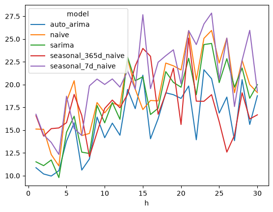

```python
by_horizon = df.groupby(['model', 'h']).abs_err.mean().unstack('model')
by_horizon.plot()
```

```python
df['month'] = df.date.dt.month
by_month = df.groupby(['model', 'month']).abs_err.mean().unstack('model')
by_month
```

| model month | auto_arima | naive | sarima | seasonal_365d_naive | seasonal_7d_naive |
| --- | --- | --- | --- | --- | --- |
| 1 | 24.510822 | 36.338710 | 46.359916 | 19.994624 | 51.655914 |
| 2 | 11.020356 | 21.205882 | 14.731050 | 16.394118 | 17.847059 |
| 3 | 12.241482 | 20.440860 | 14.472463 | 19.204301 | 16.301075 |
| 4 | 17.275937 | 19.477778 | 18.686593 | 22.211111 | 21.788889 |
| 5 | 17.546908 | 12.010753 | 14.214812 | 13.881720 | 16.354839 |
| 6 | 14.722399 | 8.694444 | 8.361276 | 14.255556 | 10.138889 |
| 7 | 13.079471 | 10.523077 | 11.653924 | 14.846154 | 15.500000 |
| 8 | 11.716777 | 12.677419 | 11.191637 | 16.564516 | 16.895161 |
| 9 | 13.603635 | 14.450000 | 12.830272 | 16.516667 | 16.900000 |
| 10 | 10.447178 | 17.302632 | 11.068813 | 16.697368 | 13.236842 |
| 11 | 12.068017 | 12.683333 | 11.691886 | 14.500000 | 13.716667 |
| 12 | 28.854555 | 38.758065 | 33.316723 | 24.688172 | 31.419355 |

```python
pc = post_covid_df.copy()
pc['year']  = pc.index.year
pc['month'] = pc.index.month

pivot = pc.pivot_table(index='month', columns='year',
                       values='headcount', aggfunc='mean').round(1)
print(pivot)
```

```
year   2022  2023  2024  2025  2026
month
1       NaN  61.5  73.2  70.3  58.6
2       NaN  70.8  80.7  70.7  53.4
3       NaN  68.6  80.6  69.3  47.2
4       NaN  60.0  59.6  63.9  36.6
5       NaN  45.2  44.1  41.6  27.9
6       NaN  40.4  38.8  37.2  17.4
7       NaN  42.1  44.3  44.6  21.5
8       NaN  49.3  50.7  47.4  25.0
9       NaN  48.9  53.8  39.7   NaN
10     37.5  52.0  63.5  48.1   NaN
11     56.2  71.5  69.8  53.8   NaN
12     66.2  75.4  70.3  63.0   NaN
```

```python
yoy = (pivot[2026] / pivot[2025]).round(3)
diff = (pivot[2026] - pivot[2025]).round(1)
print(pd.DataFrame({'ratio': yoy, 'difference': diff}))
```

```
       ratio  difference
month
1      0.834       -11.7
2      0.755       -17.3
3      0.681       -22.1
4      0.573       -27.3
5      0.671       -13.7
6      0.468       -19.8
7      0.482       -23.1
8      0.527       -22.4
9        NaN         NaN
10       NaN         NaN
11       NaN         NaN
12       NaN         NaN
```

```python
pc['doy'] = pc.index.dayofyear
fig = px.line(pc[pc.year >= 2023], x='doy', y='headcount', color='year')
fig.show()
```

```python
mstl = MSTL(post_covid_df['headcount'], periods=(7, 365)).fit()
px.line(mstl.trend, title='Deseasonalised level').show()
```

```python
ops = pc[~pc.xmas_flag].groupby('year').agg(
    days=('headcount', 'size'),
    zero_days=('headcount', lambda s: (s == 0).sum()),
    mean_all=('headcount', 'mean'),
    mean_operating=('headcount', lambda s: s[s > 0].mean()),
)
print(ops)
```

```
      days  zero_days   mean_all  mean_operating
year
2022    74          0  57.601351       57.601351
2023   364          0  57.190934       57.190934
2024   365          0  60.902740       60.902740
2025   364          0  54.199176       54.199176
2026   213          0  37.352113       37.352113
```

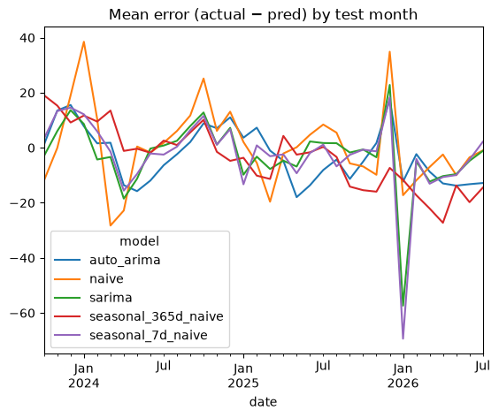

```python
results = pd.DataFrame(rows)     # instead of df = ...
results['abs_err'] = (results.actual - results.pred).abs()
results['err'] = results.actual - results.pred

by_cutoff = results.groupby(['model', results.date.dt.to_period('M')]).err.mean().unstack('model')
by_cutoff.plot(title='Mean error (actual − pred) by test month')
```